# Portfolio

## Linear Regression

```python
Xs = videoData[["participation", "confusion.points", "key.points"]].to_numpy()
watchTime = videoData.loc[:,"watch.time"].values.reshape(-1, 1)

videoModel = LinearRegression()
videoModel.fit(Xs, watchTime)
print("The intercept is: ", videoModel.intercept_)
print("The slope is: ", videoModel.coef_)
```

[output not shown]

#### OLS from statsmodels

```python
from statsmodels.api import OLS
videoModelOLS = OLS(watchTime, Xs)
videoModelOLSFit = videoModelOLS.fit()
videoModelOLSFit.summary()
```

OLS Regression Results

| Dep. Variable: | y | R-squared (uncentered): | 0.919 |
| --- | --- | --- | --- |
| Model: | OLS | Adj. R-squared (uncentered): | 0.918 |
| Method: | Least Squares | F-statistic: | 1117. |
| Date: | Fri, 10 Dec 2021 | Prob (F-statistic): | 2.36e-161 |
| Time: | 20:18:01 | Log-Likelihood: | 236.64 |
| No. Observations: | 300 | AIC: | -467.3 |
| Df Residuals: | 297 | BIC: | -456.2 |
| Df Model: | 3 |  |  |
| Covariance Type: | nonrobust |  |  |

|  | coef | std err | t | P>\|t\| | [0.025 | 0.975] |
| --- | --- | --- | --- | --- | --- | --- |
| x1 | 0.0172 | 0.026 | 0.660 | 0.509 | -0.034 | 0.068 |
| x2 | 0.8349 | 0.035 | 24.137 | 0.000 | 0.767 | 0.903 |
| x3 | -0.0326 | 0.034 | -0.945 | 0.345 | -0.100 | 0.035 |

| Omnibus: | 7.098 | Durbin-Watson: | 2.037 |
| --- | --- | --- | --- |
| Prob(Omnibus): | 0.029 | Jarque-Bera (JB): | 7.426 |
| Skew: | -0.283 | Prob(JB): | 0.0244 |
| Kurtosis: | 3.523 | Cond. No. | 7.47 |

Notes:  
[1] R² is computed without centering (uncentered) since the model does not contain a constant.  
[2] Standard Errors assume that the covariance matrix of the errors is correctly specified.

#### Interpretation of the results

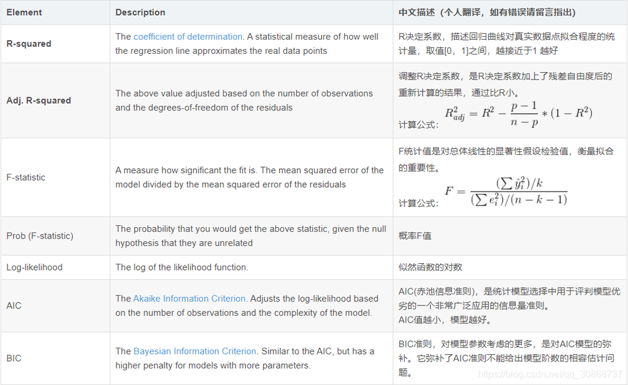

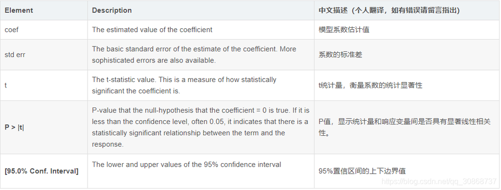

# ICE4: Classification

by Jingxuan Liao

### Objectives:

implement a binary logistic regression model to train a classifier

implement a decision tree model to train a classifier

implement a Naive Bayes model to train a classifier

report model performance on a validation dataset

## Logistic Regression

```python
import pandas as pd
import matplotlib.pyplot as plt
```

```python
mooc = pd.read_csv('ICE4_Data.csv')
mooc
```

|  | certified | forum.posts | grade | assignment |
| --- | --- | --- | --- | --- |
| 0 | no | 7 | 3 | 9 |
| 1 | no | 7 | 4 | 1 |
| 2 | yes | 191 | 8 | 19 |
| 3 | yes | 130 | 10 | 18 |
| 4 | yes | 135 | 8 | 18 |
| ... | ... | ... | ... | ... |
| 995 | yes | 88 | 10 | 13 |
| 996 | yes | 153 | 10 | 19 |
| 997 | no | 41 | 4 | 3 |
| 998 | no | 47 | 6 | 12 |
| 999 | yes | 112 | 8 | 19 |

1000 rows × 4 columns

```python
mooc['certified'].value_counts()
```

```
yes    725
no     275
Name: certified, dtype: int64
```

```python
mooc.describe()
```

|  | forum.posts | grade | assignment |
| --- | --- | --- | --- |
| count | 1000.000000 | 1000.00000 | 1000.000000 |
| mean | 113.107000 | 7.76500 | 13.693000 |
| std | 55.126477 | 2.38232 | 5.011973 |
| min | 1.000000 | 1.00000 | 1.000000 |
| 25% | 72.750000 | 8.00000 | 12.000000 |
| 50% | 118.500000 | 8.00000 | 15.000000 |
| 75% | 160.000000 | 9.00000 | 17.000000 |
| max | 200.000000 | 10.00000 | 20.000000 |

```python
import seaborn as sns
```

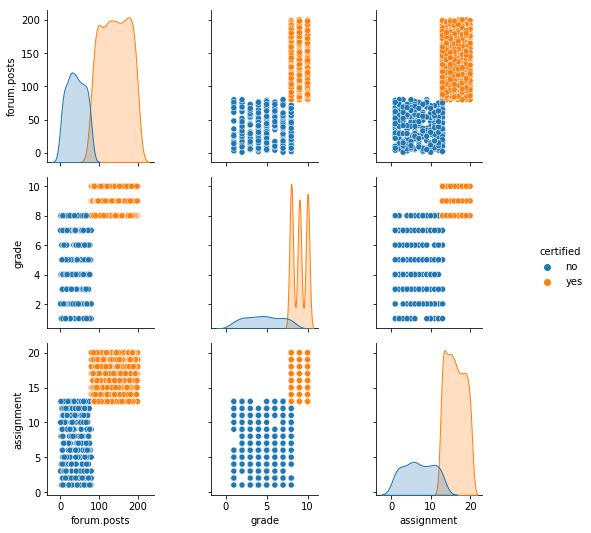

```python
sns.pairplot(mooc, hue = "certified")
```

Observation：

- From the above pairplot, the goal is to find out whether 'forum-posts' or 'assignment','grade' can predict 'certified' (yes/no).

It seems like all three variables can predict 'certified':

- In terms of forum.posts, the threshold for 'certified' is around 90-200, which means that students with forum.posts between 90-200 are more likely to be certified;
- In terms of grade, the threshold for 'certified' is around 8;
- In terms of assignment, the threshold for 'certified' is around 12.

### Method 1: Logistic Regression Binary Model

```python
from sklearn.linear_model import LogisticRegression
```

```python
dummy = pd.get_dummies(mooc['certified'], prefix = 'certified')
dummy
```

|  | certified_no | certified_yes |
| --- | --- | --- |
| 0 | 1 | 0 |
| 1 | 1 | 0 |
| 2 | 0 | 1 |
| 3 | 0 | 1 |
| 4 | 0 | 1 |
| ... | ... | ... |
| 995 | 0 | 1 |
| 996 | 0 | 1 |
| 997 | 1 | 0 |
| 998 | 1 | 0 |
| 999 | 0 | 1 |

1000 rows × 2 columns

```python
moocD = pd.concat([mooc, dummy], axis=1)
moocD = moocD.drop(['certified','certified_no'],axis=1)
moocD
```

|  | forum.posts | grade | assignment | certified_yes |
| --- | --- | --- | --- | --- |
| 0 | 7 | 3 | 9 | 0 |
| 1 | 7 | 4 | 1 | 0 |
| 2 | 191 | 8 | 19 | 1 |
| 3 | 130 | 10 | 18 | 1 |
| 4 | 135 | 8 | 18 | 1 |
| ... | ... | ... | ... | ... |
| 995 | 88 | 10 | 13 | 1 |
| 996 | 153 | 10 | 19 | 1 |
| 997 | 41 | 4 | 3 | 0 |
| 998 | 47 | 6 | 12 | 0 |
| 999 | 112 | 8 | 19 | 1 |

1000 rows × 4 columns

```python
Xs = moocD[['forum.posts','grade','assignment']].to_numpy()
certified = moocD.loc[:,'certified_yes'].values.reshape(-1,1)
Xs
```

```
array([[  7,   3,   9],
       [  7,   4,   1],
       [191,   8,  19],
       ...,
       [ 41,   4,   3],
       [ 47,   6,  12],
       [112,   8,  19]])
```

```python
moocLogitModel1 = LogisticRegression()
moocLogitModel1.fit(Xs, certified)
```

```
LogisticRegression(C=1.0, class_weight=None, dual=False, fit_intercept=True,
                   intercept_scaling=1, l1_ratio=None, max_iter=100,
                   multi_class='auto', n_jobs=None, penalty='l2',
                   random_state=None, solver='lbfgs', tol=0.0001, verbose=0,
                   warm_start=False)
```

```python
moocLogitModel1.intercept_
```

```
array([-63.13291439])
```

```python
moocLogitModel1.coef_
```

```
array([[0.62419697, 0.52270711, 0.85766257]])
```

```python
import statsmodels.api as sm
moocLogitModel2 = sm.Logit(certified, Xs)
moocLogitModel2Fit = moocLogitModel2.fit()
print(moocLogitModel2Fit.summary())
```

```
Optimization terminated successfully.
         Current function value: 22.457768
         Iterations 7
                           Logit Regression Results
==============================================================================
Dep. Variable:                      y   No. Observations:                 1000
Model:                          Logit   Df Residuals:                      997
Method:                           MLE   Df Model:                            2
Date:                Fri, 10 Dec 2021   Pseudo R-squ.:                     inf
Time:                        20:43:17   Log-Likelihood:                -22458.
converged:                       True   LL-Null:                        0.0000
Covariance Type:            nonrobust   LLR p-value:                     1.000
==============================================================================
                 coef    std err          z      P>|z|      [0.025      0.975]
------------------------------------------------------------------------------
x1             0.0378      0.003     10.852      0.000       0.031       0.045
x2            -0.3202      0.047     -6.879      0.000      -0.411      -0.229
x3             0.0315      0.025      1.258      0.208      -0.018       0.081
==============================================================================
```

## Decision Tree

```python
from sklearn.tree import DecisionTreeClassifier
Xs_tree = mooc.drop('certified', axis = 1)
certified = mooc['certified']
```

```python
moocTreeModel = DecisionTreeClassifier()
moocTreeModel.fit(Xs_tree, certified)
```

```
DecisionTreeClassifier(ccp_alpha=0.0, class_weight=None, criterion='gini',
                       max_depth=None, max_features=None, max_leaf_nodes=None,
                       min_impurity_decrease=0.0, min_impurity_split=None,
                       min_samples_leaf=1, min_samples_split=2,
                       min_weight_fraction_leaf=0.0, presort='deprecated',
                       random_state=None, splitter='best')
```

```python
from sklearn import tree
text_representation = tree.export_text(moocTreeModel)
print(text_representation)
```

```
|--- feature_0 <= 79.50
|   |--- class: no
|--- feature_0 >  79.50
|   |--- feature_1 <= 7.50
|   |   |--- class: no
|   |--- feature_1 >  7.50
|   |   |--- class: yes
```

```
[Text(136.72,187.033,'forum.posts <= 79.5\ngini = 0.399\nsamples = 1000\nvalue = [275, 725]\nclass = no'),
 Text(68.36,112.22,'gini = 0.0\nsamples = 271\nvalue = [271, 0]\nclass = no'),
 Text(205.08,112.22,'grade <= 7.5\ngini = 0.011\nsamples = 729\nvalue = [4, 725]\nclass = no'),
 Text(136.72,37.4067,'gini = 0.0\nsamples = 4\nvalue = [4, 0]\nclass = no'),
 Text(273.44,37.4067,'gini = 0.0\nsamples = 725\nvalue = [0, 725]\nclass = no')]
```

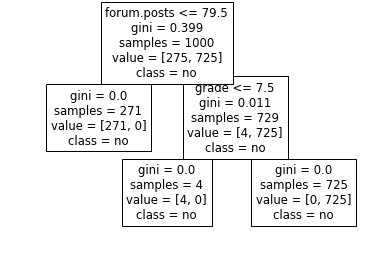

```python
tree.plot_tree(moocTreeModel,
               feature_names = ['forum.posts','grade','assignment'],
               class_names = mooc.certified)
```

## Naive Bayes

```python
moocNBModel = GaussianNB()
moocNBModel.fit(Xs_NB, certified)
```

```
GaussianNB(priors=None, var_smoothing=1e-09)
```

```python
certified_pred = moocNBModel.predict(Xs_NB)
performance = [item in certified_pred for item in certified]
print('The accuracy is', sum(performance)/len(performance)*100,'%')
```

```
The accuracy is 100.0 %
```

## Model Evaluation: Confusion Matrix

```python
from sklearn.model_selection import train_test_split

# logistic regression
Xs_logit = moocD[["forum.posts", "grade", "assignment"]].to_numpy()
certified_logit = moocD.loc[:,"certified_yes"].values.reshape(-1, 1)
xs_logit_training, xs_logit_test, y_logit_training, y_logit_test = train_test_split(Xs_logit, certified_logit, test_size = 0.2)

# Decision tree and Naive Bayes
Xs_TNB = mooc.drop('certified', axis = 1)
certified_TNB = mooc['certified']
xs_TNB_training, xs_TNB_test, y_TNB_training, y_TNB_test = train_test_split(Xs_TNB, certified_TNB, test_size = 0.2)
```

```python
# Logistic regression with sklearn
moocLogitModel3 = LogisticRegression()
moocLogitModel3.fit(xs_logit_training, y_logit_training)

moocLogitModel3.intercept_
moocLogitModel3.coef_
```

```
array([[0.59783611, 0.47817491, 0.87531256]])
```

```python
# Logistic regression with statsmodels
moocLogitModel4 = sm.Logit(y_logit_training, xs_logit_training)
moocLogitModel4Fit = moocLogitModel4.fit()
print(moocLogitModel4Fit.summary())
```

```
Optimization terminated successfully.
         Current function value: 21.529497
         Iterations 7
                           Logit Regression Results
==============================================================================
Dep. Variable:                      y   No. Observations:                  800
Model:                          Logit   Df Residuals:                      797
Method:                           MLE   Df Model:                            2
Date:                Fri, 10 Dec 2021   Pseudo R-squ.:                     inf
Time:                        20:43:18   Log-Likelihood:                -17224.
converged:                       True   LL-Null:                        0.0000
Covariance Type:            nonrobust   LLR p-value:                     1.000
==============================================================================
                 coef    std err          z      P>|z|      [0.025      0.975]
------------------------------------------------------------------------------
x1             0.0386      0.004      9.732      0.000       0.031       0.046
x2            -0.3065      0.052     -5.843      0.000      -0.409      -0.204
x3             0.0219      0.028      0.778      0.436      -0.033       0.077
==============================================================================
```

```python
# Decision Tree
moocTreeModel1 = DecisionTreeClassifier()
moocTreeModel1.fit(xs_TNB_training, y_TNB_training)
```

```
DecisionTreeClassifier(ccp_alpha=0.0, class_weight=None, criterion='gini',
                       max_depth=None, max_features=None, max_leaf_nodes=None,
                       min_impurity_decrease=0.0, min_impurity_split=None,
                       min_samples_leaf=1, min_samples_split=2,
                       min_weight_fraction_leaf=0.0, presort='deprecated',
                       random_state=None, splitter='best')
```

```python
text_representation1 = tree.export_text(moocTreeModel1)
print(text_representation1)
```

```
|--- feature_0 <= 79.50
|   |--- class: no
|--- feature_0 >  79.50
|   |--- feature_1 <= 7.50
|   |   |--- class: no
|   |--- feature_1 >  7.50
|   |   |--- class: yes
```

```
[Text(136.72,187.033,'forum.posts <= 79.5\ngini = 0.408\nsamples = 800\nvalue = [228, 572]\nclass = no'),
 Text(68.36,112.22,'gini = 0.0\nsamples = 225\nvalue = [225, 0]\nclass = no'),
 Text(205.08,112.22,'grade <= 7.5\ngini = 0.01\nsamples = 575\nvalue = [3, 572]\nclass = no'),
 Text(136.72,37.4067,'gini = 0.0\nsamples = 3\nvalue = [3, 0]\nclass = no'),
 Text(273.44,37.4067,'gini = 0.0\nsamples = 572\nvalue = [0, 572]\nclass = no')]
```

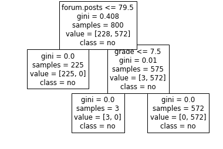

```python
tree.plot_tree(moocTreeModel1,
              feature_names = ["forum.posts", "grade", "assignment"],
                class_names = mooc.certified)
```

```python
# Naive Bayes
moocNBModel1 = GaussianNB()
moocNBModel1.fit(xs_TNB_training, y_TNB_training)
```

```
GaussianNB(priors=None, var_smoothing=1e-09)
```

### Confusion Matrix

```python
from sklearn.metrics import confusion_matrix
```

```python
# sklearn logistic regression model confusion matrix
print(confusion_matrix(y_logit_test, certified_pred_logit1))
```

```
[[ 54   0]
 [  0 146]]
```

```python
# statsmodels logistic regression model confusion matrix
print(confusion_matrix(y_logit_test, certified_pred_logit2))
```

```
[[ 54   0]
 [  0 146]]
```

```python
# decision tree model confusion matrix
print(confusion_matrix(y_TNB_test, certified_pred_tree))
```

```
[[ 55   0]
 [  0 145]]
```

```python
# Naive Bayes confusion matrix
print(confusion_matrix(y_TNB_test, certified_pred_TNB))
```

```
[[ 55   0]
 [  0 145]]
```

### Accuracy Score

```python
from sklearn.metrics import accuracy_score
ac_logit1 = accuracy_score(y_logit_test, certified_pred_logit1)
ac_logit2 = accuracy_score(y_logit_test, certified_pred_logit2)
ac_tree = accuracy_score(y_TNB_test, certified_pred_tree)
ac_TNB = accuracy_score(y_TNB_test, certified_pred_TNB)

print("The accuracy for logistic regression in sklearn is", ac_logit1*100, "%")
print("The accuracy for logistic regression in statsmodels is", ac_logit2*100, "%")
print("The accuracy for decision tree", ac_tree*100, "%")
print("The accuracy for naive bayes", ac_TNB*100, "%")
```

```
The accuracy for logistic regression in sklearn is 100.0 %
The accuracy for logistic regression in statsmodels is 100.0 %
The accuracy for decision tree 100.0 %
The accuracy for naive bayes 100.0 %
```

# ICE5: Clustering

```python
By Jingxuan Liao
```

```python
import matplotlib.pyplot as plt
import pandas as pd
import numpy as np
```

```python
from sklearn.datasets import make_blobs

twoDData, cluster_true = make_blobs(n_samples = 300, centers = 4,
                                   cluster_std = 0.5, random_state = 0)

print("Here are the first 10 rows of twoDData:")
print(twoDData[:10])
print("Here are the true labels for each observation. But we don't need it.")
print(cluster_true[:10])
```

```
Here are the first 10 rows of twoDData:
[[ 1.03992529  1.92991009]
 [-1.38609104  7.48059603]
 [ 1.12538917  4.96698028]
 [-1.05688956  7.81833888]
 [ 1.4020041   1.726729  ]
 [ 3.20722587  0.36765575]
 [-1.76133611  1.81716162]
 [ 1.34081536  4.36827878]
 [-0.37881944  8.33265721]
 [-0.80062564  8.52294205]]
Here are the true labels for each observation. But we don't need it.
[1 3 0 3 1 1 2 0 3 3]
```

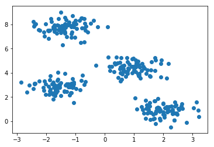

```python
plt.scatter(twoDData[:,0],twoDData[:,1]);
```

```python
from sklearn.cluster import KMeans
```

```python
kmeans = KMeans(n_clusters=4)
kmeans.fit(twoDData)
cluster_kmeans = kmeans.predict(twoDData)
```

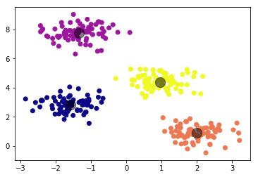

```python
plt.scatter(twoDData[:,0],twoDData[:,1],c=cluster_kmeans,cmap='plasma')
centers = kmeans.cluster_centers_
plt.scatter(centers[:,0],centers[:,1],c='black',s=200,alpha=0.5)
```

## Silhoutte Coefficient and Silhoutte Plot

```python
from sklearn.metrics import silhouette_score

silhouetteScore = silhouette_score(twoDData,cluster_kmeans, metric='euclidean')

print('Silhouette Score:',silhouetteScore)
```

```
Silhouette Score: 0.7356713838266389
```

```python
from yellowbrick.cluster import SilhouetteVisualizer
```

```python
smodel = kmeans
visualizer = SilhouetteVisualizer(smodel, colors='yellowbrick')
```

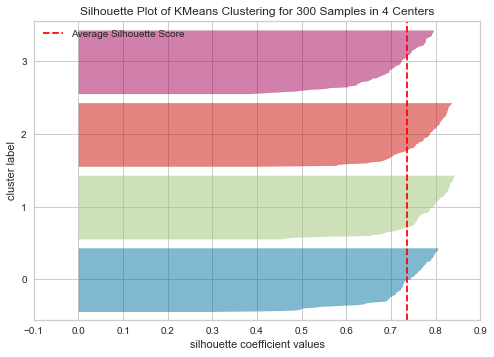

```python
visualizer.fit(twoDData)
visualizer.show()
```

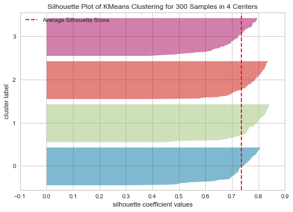

```
SilhouetteVisualizer(ax=<matplotlib.axes._subplots.AxesSubplot object at 0x7f1c72797cf8>,
                     colors='yellowbrick',
                     estimator=KMeans(algorithm='auto', copy_x=True,
                                      init='k-means++', max_iter=300,
                                      n_clusters=4, n_init=10, n_jobs=None,
                                      precompute_distances='auto',
                                      random_state=None, tol=0.0001,
                                      verbose=0),
                     is_fitted='auto')
```

```python
from yellowbrick.cluster import silhouette_visualizer
silhouette_visualizer(kmeans, twoDData, colors='yellowbrick')
```

## Clustering with k-Means: Self-Reported Motivation

```python
mtv = pd.read_csv('ICE5_Data.csv')
mtv
```

|  | id | motivation1 | motivation2 | motivation3 | motivation4 | motivation5 |
| --- | --- | --- | --- | --- | --- | --- |
| 0 | 10005216 | 2 | 2.0 | 2 | 2.0 | 2.0 |
| 1 | 10033216 | 3 | NaN | 3 | NaN | NaN |
| 2 | 10004216 | 1 | 2.0 | 1 | 2.0 | 2.0 |
| 3 | 10008216 | 1 | 2.0 | 1 | 2.0 | NaN |
| 4 | 10026216 | 3 | NaN | 3 | NaN | NaN |
| 5 | 10014216 | 2 | NaN | 2 | NaN | 2.0 |
| 6 | 10021216 | 2 | 2.0 | 2 | 2.0 | 2.0 |
| 7 | 10013216 | 2 | NaN | 2 | NaN | 1.0 |
| 8 | 10035216 | 2 | 3.0 | 2 | 3.0 | NaN |
| 9 | 10015216 | 2 | 2.0 | 2 | 2.0 | 2.0 |
| 10 | 10031216 | 1 | 1.0 | 1 | 1.0 | NaN |
| 11 | 10007216 | 2 | 1.0 | 2 | 1.0 | 2.0 |
| 12 | 10010216 | 2 | 2.0 | 2 | 2.0 | NaN |
| 13 | 10020216 | 2 | 3.0 | 2 | 3.0 | 1.0 |
| 14 | 10002216 | 1 | 1.0 | 1 | 1.0 | 4.0 |
| 15 | 10011216 | 2 | 2.0 | 2 | 2.0 | NaN |
| 16 | 10023216 | 1 | 1.0 | 1 | 1.0 | 3.0 |
| 17 | 10028216 | 1 | 1.0 | 1 | 1.0 | 1.0 |
| 18 | 10028216 | 1 | 1.0 | 1 | 1.0 | 1.0 |
| 19 | 10034216 | 3 | 2.0 | 3 | 2.0 | 2.0 |
| 20 | 10003216 | 2 | NaN | 2 | NaN | NaN |
| 21 | 10029216 | 2 | 2.0 | 2 | 2.0 | 5.0 |
| 22 | 10022216 | 1 | 3.0 | 1 | 3.0 | NaN |
| 23 | 10006216 | 1 | 1.0 | 1 | 1.0 | NaN |
| 24 | 10009216 | 1 | 1.0 | 1 | 1.0 | 2.0 |
| 25 | 10018216 | 1 | 2.0 | 1 | 2.0 | 4.0 |
| 26 | 10018216 | 1 | 2.0 | 1 | 2.0 | 3.0 |
| 27 | 10018216 | 1 | 2.0 | 1 | 2.0 | 4.0 |
| 28 | 10018216 | 1 | 2.0 | 1 | 2.0 | 3.0 |
| 29 | 10018216 | 1 | 2.0 | 1 | 2.0 | 4.0 |
| 30 | 10018216 | 1 | 2.0 | 1 | 2.0 | 3.0 |
| 31 | 10018216 | 1 | 2.0 | 1 | 2.0 | 4.0 |
| 32 | 10018216 | 1 | 2.0 | 1 | 2.0 | 3.0 |
| 33 | 10027216 | 1 | 1.0 | 1 | 1.0 | 1.0 |
| 34 | 10025216 | 2 | 2.0 | 2 | 2.0 | 2.0 |
| 35 | 10019216 | 1 | NaN | 1 | NaN | NaN |
| 36 | 10032216 | 3 | NaN | 3 | NaN | NaN |
| 37 | 10017216 | 3 | NaN | 3 | NaN | 3.0 |

```python
mtv = mtv.dropna()
mtv = mtv.drop(['id'],axis = 1)
mtv
```

|  | motivation1 | motivation2 | motivation3 | motivation4 | motivation5 |
| --- | --- | --- | --- | --- | --- |
| 0 | 2 | 2.0 | 2 | 2.0 | 2.0 |
| 2 | 1 | 2.0 | 1 | 2.0 | 2.0 |
| 6 | 2 | 2.0 | 2 | 2.0 | 2.0 |
| 9 | 2 | 2.0 | 2 | 2.0 | 2.0 |
| 11 | 2 | 1.0 | 2 | 1.0 | 2.0 |
| 13 | 2 | 3.0 | 2 | 3.0 | 1.0 |
| 14 | 1 | 1.0 | 1 | 1.0 | 4.0 |
| 16 | 1 | 1.0 | 1 | 1.0 | 3.0 |
| 17 | 1 | 1.0 | 1 | 1.0 | 1.0 |
| 18 | 1 | 1.0 | 1 | 1.0 | 1.0 |
| 19 | 3 | 2.0 | 3 | 2.0 | 2.0 |
| 21 | 2 | 2.0 | 2 | 2.0 | 5.0 |
| 24 | 1 | 1.0 | 1 | 1.0 | 2.0 |
| 25 | 1 | 2.0 | 1 | 2.0 | 4.0 |
| 26 | 1 | 2.0 | 1 | 2.0 | 3.0 |
| 27 | 1 | 2.0 | 1 | 2.0 | 4.0 |
| 28 | 1 | 2.0 | 1 | 2.0 | 3.0 |
| 29 | 1 | 2.0 | 1 | 2.0 | 4.0 |
| 30 | 1 | 2.0 | 1 | 2.0 | 3.0 |
| 31 | 1 | 2.0 | 1 | 2.0 | 4.0 |
| 32 | 1 | 2.0 | 1 | 2.0 | 3.0 |
| 33 | 1 | 1.0 | 1 | 1.0 | 1.0 |
| 34 | 2 | 2.0 | 2 | 2.0 | 2.0 |

```python
mtvkmeans2 = KMeans(n_clusters=2)
mtvkmeans2.fit(mtv)
cluster_mtv2 = mtvkmeans2.predict(mtv)
```

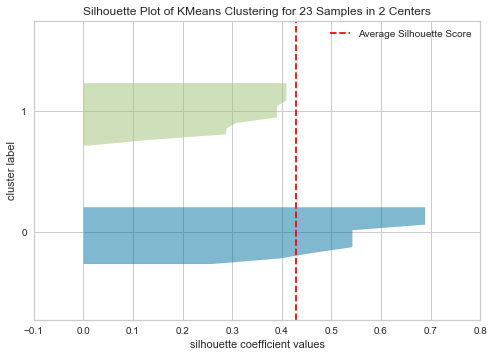

```
Silhouette Score is 0.4278253443934091
```

```python
silhouette_visualizer(mtvkmeans2,mtv,colors='yellowbrick')
silhouetteScore2 = silhouette_score(mtv,cluster_mtv2,metric='euclidean')
print('Silhouette Score is',silhouetteScore2)
```

```python
mtvkmeans3 = KMeans(n_clusters=3)
mtvkmeans3.fit(mtv)
cluster_mtv3 = mtvkmeans3.predict(mtv)
```

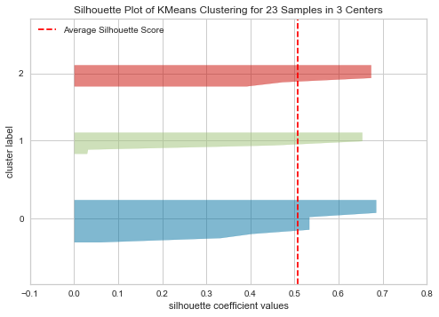

```
Silhouette Score is 0.5078715772811808
```

```python
silhouette_visualizer(mtvkmeans3,mtv,colors='yellowbrick')
silhouetteScore3 = silhouette_score(mtv,cluster_mtv3,metric='euclidean')
print('Silhouette Score is',silhouetteScore3)
```

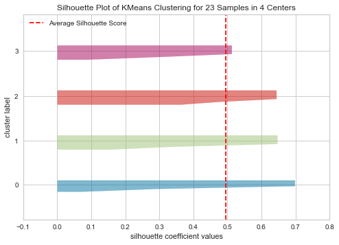

```
Silhouette Score is 0.49488453159748896
```

```python
mtvkmeans4 = KMeans(n_clusters=4)
mtvkmeans4.fit(mtv)
cluster_mtv4 = mtvkmeans4.predict(mtv)
silhouette_visualizer(mtvkmeans4,mtv,colors='yellowbrick')
silhouetteScore4 = silhouette_score(mtv,cluster_mtv4,metric='euclidean')
print('Silhouette Score is',silhouetteScore4)
```

```python
print('Silhouette Score is',silhouetteScore2)
print('Silhouette Score is',silhouetteScore3)
print('Silhouette Score is',silhouetteScore4)
```

```
Silhouette Score is 0.4278253443934091
Silhouette Score is 0.5078715772811808
Silhouette Score is 0.49488453159748896
```

```python
# silhouetteScore3 has the highest score
mtv3cluster = mtv.copy(deep=True)
mtv3cluster['cluster'] = cluster_mtv3
mtv3cluster
```

|  | motivation1 | motivation2 | motivation3 | motivation4 | motivation5 | cluster |
| --- | --- | --- | --- | --- | --- | --- |
| 0 | 2 | 2.0 | 2 | 2.0 | 2.0 | 2 |
| 2 | 1 | 2.0 | 1 | 2.0 | 2.0 | 1 |
| 6 | 2 | 2.0 | 2 | 2.0 | 2.0 | 2 |
| 9 | 2 | 2.0 | 2 | 2.0 | 2.0 | 2 |
| 11 | 2 | 1.0 | 2 | 1.0 | 2.0 | 1 |
| 13 | 2 | 3.0 | 2 | 3.0 | 1.0 | 2 |
| 14 | 1 | 1.0 | 1 | 1.0 | 4.0 | 0 |
| 16 | 1 | 1.0 | 1 | 1.0 | 3.0 | 0 |
| 17 | 1 | 1.0 | 1 | 1.0 | 1.0 | 1 |
| 18 | 1 | 1.0 | 1 | 1.0 | 1.0 | 1 |
| 19 | 3 | 2.0 | 3 | 2.0 | 2.0 | 2 |
| 21 | 2 | 2.0 | 2 | 2.0 | 5.0 | 0 |
| 24 | 1 | 1.0 | 1 | 1.0 | 2.0 | 1 |
| 25 | 1 | 2.0 | 1 | 2.0 | 4.0 | 0 |
| 26 | 1 | 2.0 | 1 | 2.0 | 3.0 | 0 |
| 27 | 1 | 2.0 | 1 | 2.0 | 4.0 | 0 |
| 28 | 1 | 2.0 | 1 | 2.0 | 3.0 | 0 |
| 29 | 1 | 2.0 | 1 | 2.0 | 4.0 | 0 |
| 30 | 1 | 2.0 | 1 | 2.0 | 3.0 | 0 |
| 31 | 1 | 2.0 | 1 | 2.0 | 4.0 | 0 |
| 32 | 1 | 2.0 | 1 | 2.0 | 3.0 | 0 |
| 33 | 1 | 1.0 | 1 | 1.0 | 1.0 | 1 |
| 34 | 2 | 2.0 | 2 | 2.0 | 2.0 | 2 |

```python
# Use elbow method
from sklearn.cluster import KMeans
from sklearn import metrics
from scipy.spatial.distance import cdist
```

[output not shown]

```python
x1 = mtv.to_numpy()
x1
```

```
array([[2., 2., 2., 2., 2.],
       [1., 2., 1., 2., 2.],
       [2., 2., 2., 2., 2.],
       [2., 2., 2., 2., 2.],
       [2., 1., 2., 1., 2.],
       [2., 3., 2., 3., 1.],
       [1., 1., 1., 1., 4.],
       [1., 1., 1., 1., 3.],
       [1., 1., 1., 1., 1.],
       [1., 1., 1., 1., 1.],
       [3., 2., 3., 2., 2.],
       [2., 2., 2., 2., 5.],
       [1., 1., 1., 1., 2.],
       [1., 2., 1., 2., 4.],
       [1., 2., 1., 2., 3.],
       [1., 2., 1., 2., 4.],
       [1., 2., 1., 2., 3.],
       [1., 2., 1., 2., 4.],
       [1., 2., 1., 2., 3.],
       [1., 2., 1., 2., 4.],
       [1., 2., 1., 2., 3.],
       [1., 1., 1., 1., 1.],
       [2., 2., 2., 2., 2.]])
```

# ICE6: Principal Component Anaysis

by Jingxuan Liao

```python
import pandas as pd
import numpy as np
from matplotlib import pyplot as plt
```

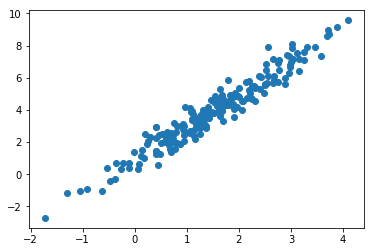

```python
np.random.seed(123)
X = np.random.randn(200) + 1.5
res = 0.6 * np.random.randn(200)
y = 1 + 2 * X + res
twoDData = np.c_[X,y]
plt.scatter(twoDData[:, 0], twoDData[:, 1])
```

```python
from sklearn.decomposition import PCA
pca = PCA(n_components=2)
pca.fit(twoDData)
print(pca.components_)
```

```
[[-0.42728651 -0.90411627]
 [-0.90411627  0.42728651]]
```

```python
print(pca.explained_variance_)
```

```
[5.83154391 0.05919512]
```

```python
pca = PCA(n_components=1)
pca.fit(twoDData)
twoDData_dr = pca.transform(twoDData)
print("original shape:   ", twoDData.shape)
print("transformed shape:", twoDData_dr.shape)
```

```
original shape:    (200, 2)
transformed shape: (200, 1)
```

## PCA for Dimension Reduction

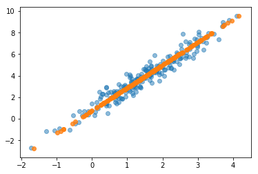

```python
twoDData_new = pca.inverse_transform(twoDData_dr)
plt.scatter(twoDData[:, 0], twoDData[:, 1], alpha=0.5)
plt.scatter(twoDData_new[:, 0], twoDData_new[:, 1], alpha=0.8)
```

```python
ICEdata = pd.read_csv("ICE6_Data.csv")
ICEdata
```

|  | id | prior_prob_count | prior_percent_correct | problems_attempted | mean_correct | mean_hint | mean_attempt | mean_confidence |
| --- | --- | --- | --- | --- | --- | --- | --- | --- |
| 0 | 172777 | 650 | 0.723077 | 4 | 1.000000 | 0.000000 | 1.000000 | 0.550159 |
| 1 | 175658 | 1159 | 0.800690 | 22 | 0.454545 | 2.227273 | 1.227273 | 0.437515 |
| 2 | 175669 | 1239 | 0.656981 | 11 | 0.636364 | 1.363636 | 1.727273 | 0.511060 |
| 3 | 176151 | 1246 | 0.729535 | 16 | 0.750000 | 0.562500 | 1.187500 | 0.491578 |
| 4 | 176165 | 1299 | 0.568129 | 6 | 0.333333 | 2.166667 | 2.000000 | 0.409887 |
| ... | ... | ... | ... | ... | ... | ... | ... | ... |
| 337 | 253464 | 9 | 0.222222 | 23 | 0.782609 | 0.000000 | 1.347826 | 0.602103 |
| 338 | 253517 | 6 | 0.833333 | 16 | 0.562500 | 0.562500 | 2.062500 | 0.571269 |
| 339 | 255494 | 12 | 0.750000 | 3 | 0.666667 | 0.666667 | 1.333333 | 0.563379 |
| 340 | 256227 | 84 | 0.678571 | 3 | 0.333333 | 1.666667 | 1.333333 | 0.567501 |
| 341 | 257289 | 20 | 1.000000 | 4 | 1.000000 | 0.000000 | 1.000000 | 0.439283 |

342 rows × 8 columns

```python
ICEdata_noid = ICEdata.drop(['id'], axis = 1)
icepca = PCA(n_components=7)
icepca.fit(ICEdata_noid)

print("The principal components are:")
print(icepca.components_)
print("The explained variances are:")
print(icepca.explained_variance_)
```

```
The principal components are:
[[ 9.99998379e-01  3.25231653e-05  1.72229676e-03  6.65415156e-05
   4.97054823e-04  1.49367002e-04  1.15030348e-05]
 [-1.73541120e-03  1.03037706e-03  9.99602228e-01  2.30861751e-03
   2.23020180e-02  1.69662730e-02 -8.64582845e-04]
 [-3.87330335e-04 -3.27396081e-02 -2.70451869e-02 -1.24635620e-01
   6.73010236e-01  7.27812593e-01  2.92226368e-03]
 [ 2.29120283e-04  3.26414469e-02  3.68040760e-03  1.78860696e-01
  -7.05688901e-01  6.84765009e-01  5.46329794e-03]
 [ 1.63571033e-04 -1.96336169e-01  6.70115719e-03 -9.52166155e-01
  -2.19898499e-01  3.19977181e-02 -7.35362922e-02]
 [ 1.91456302e-05 -9.79282671e-01  7.60612436e-04  1.99617334e-01
  -2.17110326e-03 -7.96442781e-03  3.30097853e-02]
 [ 1.73255132e-06 -1.78647923e-02 -1.39538358e-03  7.74726598e-02
   1.42375081e-02  3.24800341e-03 -9.96726458e-01]]
The explained variances are:
[1.01909636e+05 9.65917304e+01 8.07223611e-01 4.21069102e-01
 4.13364216e-02 1.60996431e-02 1.08938450e-02]
```

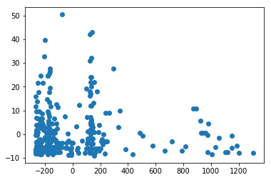

```python
icedata_dr = icepca.transform(ICEdata_noid)
plt.scatter(icedata_dr[:,0], icedata_dr[:,1])
```

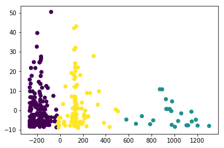

```python
from sklearn.cluster import KMeans

kmeans = KMeans(n_clusters=3)
kmeans.fit(icedata_dr)
cluster_kmeans = kmeans.predict(icedata_dr)

plt.scatter(icedata_dr[:, 0], icedata_dr[:, 1], c=cluster_kmeans, cmap='viridis')
```

(1) What could the two dimensions mean?

(2) How would you intepret the KMeans clustering?

# ICE7: Diagnostic Metrics Diagnostic Metrics

By Jingxuan Liao

- #### ACA2:
  - Y = 'ontaks'
  - Xs = 'NumACTIVITIES', 'FORMATchanges', 'NumFORMATS', 'Activity'
  - #### Model: Logistic Regression Model
  - #### Evaluation: ROC

#### ROC Curves:

It is a plot of the false positive rate (x-axis) versus the true positive rate (y-axis) for a number of different candidate threshold values between 0.0 and 1.0. Put another way, it plots the false alarm rate versus the hit rate.

```python
import pandas as pd
```

```python
valid_behavior = pd.read_csv('../ACA/ACA2/aca2_dataset_validation.csv')
valid_behavior
# we only need 4 variables
new_valid_behavior = valid_behavior[['UNIQUEID','NumACTIVITIES','FORMATchanges','NumFORMATS','Activity','ONTASK']]
new_valid_behavior.set_index('UNIQUEID', inplace=True)
```

```python
from sklearn.preprocessing import LabelEncoder, OneHotEncoder
encoder_x=LabelEncoder()
new_valid_behavior['Activity']=encoder_x.fit_transform(new_valid_behavior['Activity'])
new_valid_behavior['ONTASK']=encoder_x.fit_transform(new_valid_behavior['ONTASK'])
new_valid_behavior
```

| UNIQUEID | NumACTIVITIES | FORMATchanges | NumFORMATS | Activity | ONTASK |
| --- | --- | --- | --- | --- | --- |
| 20774 | 2 | 1 | 2 | 4 | 1 |
| 30961 | 4 | 3 | 4 | 5 | 1 |
| 35767 | 4 | 2 | 3 | 4 | 1 |
| 19990 | 3 | 0 | 1 | 4 | 0 |
| 18668 | 4 | 2 | 3 | 1 | 1 |
| ... | ... | ... | ... | ... | ... |
| 21660 | 1 | 0 | 1 | 3 | 1 |
| 21662 | 1 | 0 | 1 | 3 | 1 |
| 21665 | 1 | 0 | 1 | 3 | 0 |
| 21682 | 1 | 0 | 1 | 3 | 1 |
| 21683 | 1 | 0 | 1 | 3 | 1 |

5547 rows × 5 columns

```python
# roc curve and auc
from sklearn.datasets import make_classification
from sklearn.linear_model import LogisticRegression
from sklearn.model_selection import train_test_split
from sklearn.metrics import roc_curve
from sklearn.metrics import roc_auc_score
from matplotlib import pyplot
```

```python
# build logistic regression model
on_task = new_valid_behavior.loc[:,"ONTASK"].values.reshape(-1, 1)
Xs = new_valid_behavior[['NumACTIVITIES','FORMATchanges','NumFORMATS','Activity']]

model_behavior = LogisticRegression()
model_behavior.fit(Xs, on_task)

# predict probabilities
probs = model_behavior.predict_proba(Xs)
# keep probabilities for the positive outcome only
probs = probs[:, 1]

# calculate scores
y = new_valid_behavior['ONTASK']
auc = roc_auc_score(y, probs)

print('Logistic: ROC AUC=%.3f' % (auc))
```

```
Logistic: ROC AUC=0.525
```

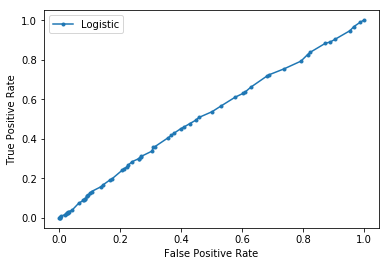

```python
# calculate roc curves
fpr, tpr, _ = roc_curve(y, probs)

# plot the roc curve for the model
pyplot.plot(fpr, tpr, marker='.', label='Logistic')

# axis labels
pyplot.xlabel('False Positive Rate')
pyplot.ylabel('True Positive Rate')

# show the legend
pyplot.legend()
# show the plot
pyplot.show()
```

### To evaluate ACA3, we use scree plot

```python
from scipy import stats
%matplotlib notebook
```

Here is the sclaed score card in ACA3 after cleaning

```python
score_card_scaled3
```

[output not shown]

### PCA: Scree plot

to determine how many dimensions is best.

Now, our data is standardized. We can do PCA now. To see which components are influential, we decide to do a scree plot to determine the number of components we want to take in PCA.

```python
pca = PCA()

pca.fit(score_card_scaled3)
```

```
PCA()
```

```python
pca.explained_variance_ratio_
```

```
array([0.21145735, 0.12632187, 0.11401067, 0.08119836, 0.07814433,
       0.0701871 , 0.05910204, 0.04678688, 0.04007572, 0.03748984,
       0.03034546, 0.02854984, 0.02363901, 0.01823988, 0.01427397,
       0.01177787, 0.00382817, 0.00345723, 0.00111443, 0.        ])
```

Here is scree plot.

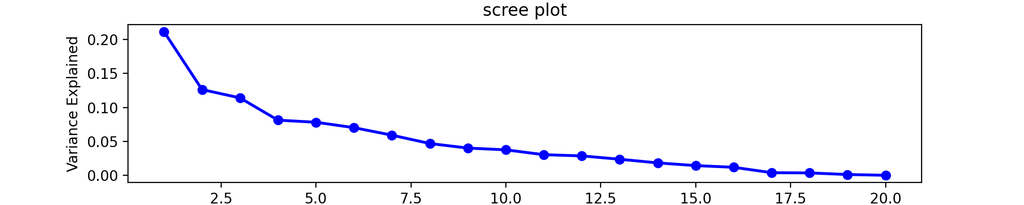

```
None
```

```python
plt.figure(figsize = (10,2))
plt.plot(range(1,21), pca.explained_variance_ratio_, 'o-', linewidth=2, color='blue')
plt.title('scree plot')
plt.xlabel('Principal Component')
plt.ylabel('Variance Explained')
print(plt.show())
```

We also set a cumulative variance figure to see how many components we need to consider in PCA.

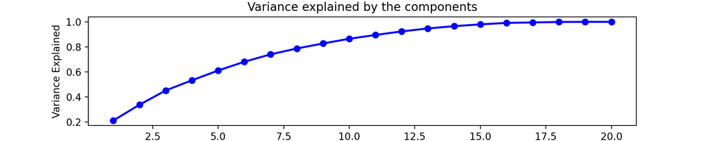

```
None
```

```python
plt.figure(figsize = (10,2))
plt.plot(range(1,21), pca.explained_variance_ratio_.cumsum(), 'o-', linewidth=2, color='blue')
plt.title('Variance explained by the components')
plt.xlabel('Principal Component')
plt.ylabel('Variance Explained')
print(plt.show())
```

```python
from matplotlib import pyplot as plt
from sklearn.decomposition import PCA
```

```python
acapca = PCA(n_components=8)
acapca.fit(score_card_scaled3)
print("The principal components are:")
print(acapca.components_)
print("The explained variances are:")
print(acapca.explained_variance_)
```

```
The principal components are:
[[ 0.34784241  0.28746632  0.44281662 -0.20339381 -0.15702734  0.33510398
  -0.00320724  0.1200449   0.2483249   0.24999967 -0.28862845 -0.04708671
   0.16826225  0.01750352 -0.12636174  0.24536192 -0.11505153  0.10124458
   0.26377182  0.        ]
 [ 0.06525975  0.04873873  0.15649433 -0.06569238 -0.04532866  0.19695762
  -0.35476374  0.29618705 -0.3114737  -0.31569632 -0.03852271 -0.12524064
  -0.0161465   0.40446523  0.45665706  0.07930042  0.3178784   0.07674189
  -0.10327811  0.        ]
 [ 0.12934601  0.11733995  0.05880862 -0.02995474 -0.06353217  0.35205345
   0.27892079 -0.402      -0.37875819 -0.37765886 -0.22118951 -0.0204496
   0.11654522 -0.1601245  -0.06819266 -0.25535132 -0.17275478  0.22421759
  -0.27045246 -0.        ]
 [-0.08360164 -0.10129399  0.08136513 -0.00935699  0.01914486 -0.20645072
  -0.23266263  0.06407344 -0.21023454 -0.20700516  0.14435664 -0.32444322
   0.59297441 -0.00866117 -0.13976876 -0.17141891 -0.28775613 -0.04609201
   0.41967048  0.        ]
 [ 0.24635768  0.24584721 -0.02576463 -0.07584483 -0.0959652  -0.17124745
   0.3060206   0.33870056 -0.25275511 -0.25369704 -0.00639992  0.05011888
  -0.00197482 -0.16599883 -0.17696827  0.16010477  0.10732657 -0.62940163
  -0.05072167  0.        ]
 [-0.22640255 -0.20713267 -0.20491056  0.04244222 -0.01439123  0.2079434
  -0.36942147  0.27553018 -0.14652606 -0.1303712  -0.24157328  0.04208964
  -0.08955944 -0.2796522  -0.41561043  0.43097714 -0.1397671   0.15327622
  -0.14102429  0.        ]
 [-0.14927981 -0.21402677  0.26306498 -0.05148049 -0.05954071  0.25047503
  -0.32331179 -0.08234799  0.17500115  0.16022332 -0.1132821  -0.01836817
   0.16281547 -0.0671049  -0.05628467 -0.33381516  0.04753914 -0.55410039
  -0.39760947 -0.        ]
 [ 0.08823834  0.11961484 -0.04762139  0.05434424  0.08171094  0.06177021
  -0.03441453  0.25812738  0.02096306  0.01525899  0.07341084 -0.10992737
  -0.34248409  0.2374139   0.1266922  -0.14448118 -0.79384135 -0.11155552
  -0.1517176  -0.        ]]
The explained variances are:
[3.1462845  1.87954934 1.69637045 1.20815448 1.16271334 1.04431736
 0.87938218 0.69614429]
```

After we got the principal components, we want to make a biplot to visualize each components. The code was refered from online learning website.

```python
def biplot(score,coeff,pcax,pcay,labels=None):
    pca1=pcax-1
    pca2=pcay-1
    xs = score[:,pca1]
    ys = score[:,pca2]
    n=score.shape[1]
    scalex = 1.0/(xs.max()- xs.min())
    scaley = 1.0/(ys.max()- ys.min())
    plt.scatter(xs*scalex,ys*scaley)
    for i in range(n):
        plt.arrow(0, 0, coeff[i,pca1], coeff[i,pca2],color='black',alpha=0.5)
        if labels is None:
            plt.text(coeff[i,pca1]* 1.15, coeff[i,pca2] * 1.15, "Var"+str(i+1), color='r', ha='center', va='center')
        else:
            plt.text(coeff[i,pca1]* 1.15, coeff[i,pca2] * 1.15, labels[i], color='g', ha='center', va='center')
    plt.xlim(-1,1)
    plt.ylim(-1,1)
    plt.xlabel("PC{}".format(pcax))
    plt.ylabel("PC{}".format(pcay))
    fig2 = plt.grid()
```

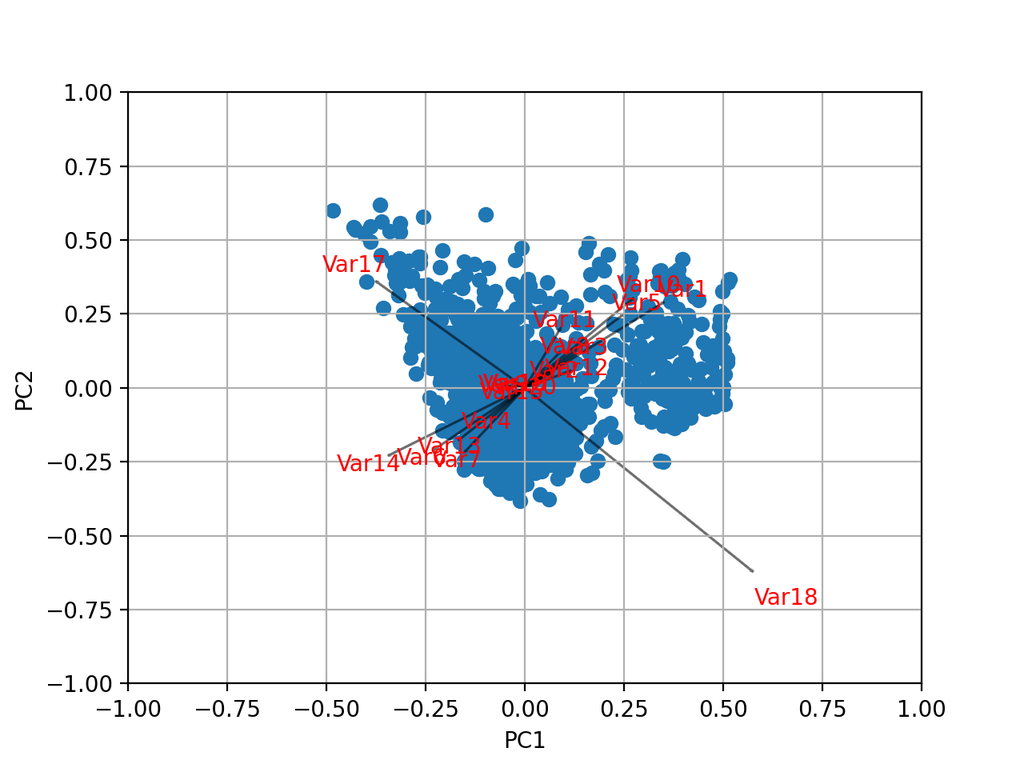

```python
biplot(pca.transform(score_card_scaled3),pca.components_,1,2)
```

### PCA: Dimension Reduction

Now, we use pca to do the dimensio reduction.

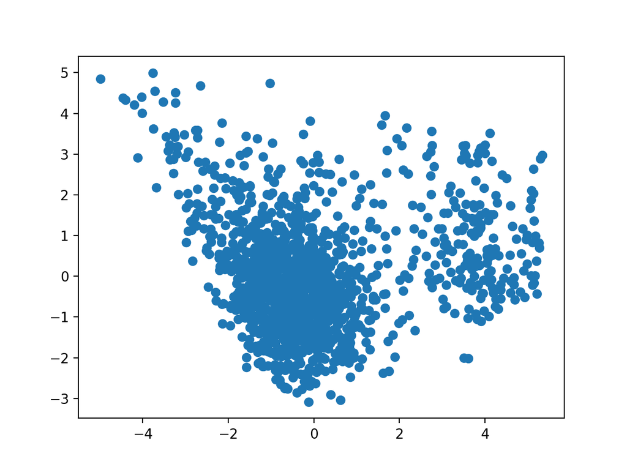

```python
acadata_dr = acapca.transform(score_card_scaled3)
plt.scatter(acadata_dr[:,0], acadata_dr[:,1])
```

Now, we use sklearn (k-mean) to cluster the data.

### K-mean cluster by PCA result

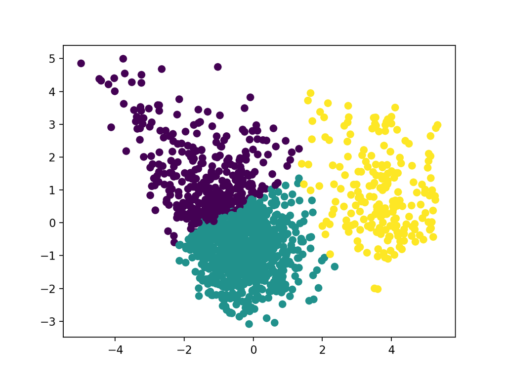

```python
from sklearn.cluster import KMeans
kmeans = KMeans(n_clusters=3)
kmeans.fit(acadata_dr)
cluster_kmeans = kmeans.predict(acadata_dr)
plt.scatter(acadata_dr[:, 0], acadata_dr[:, 1], c=cluster_kmeans, cmap='viridis') # Use cluster_means as the indicator for clusters
```

After we test severl number of clusters, we think 2 or 3 clusters are good. However, we think 3 clusters are better than 2. Thus we set n_clusters = 3.

These clusters show the main variances from the consideration of necessary components. The universities are colleges are divided into three clusters in a two-dimensional graph. When we consider a school, we can analyze according to the principal components, and fit the school into one of the clusters to help us to gain more insights on evaluation. From the variances after PCA, we can see the first two variances are higher than the rest, we also can say that the first two components could have more impact on variance than any pairs of others. The most influential components are shown in our biplot. However, 2D-dimension plots might not be the best fit if we consider the case when 8 components are considered. We include as many variables as we can to build the object model for underprivileged populations' decision making

# ICE8: Social Network Analysis

```python
import networkx as nx
import pandas as pd
import numpy as np
import matplotlib.pyplot as plt
```

```python
SNAdata = pd.read_csv("ICE8_Data.csv", index_col = 0)
SNAdata
```

|  | Nicolas Dussaillant | Ming Chen | Rebecca | Nikita Tejwani | Simon Chen | Pooja Addla | honglin | Karl | sicheng xu | Jianan Dingqian | Siyu Lin | Ziqing Yuan | Jingfei Chen | Mina Choi | Cleo You | Deji | Kan Yamane | YUNWEI ZHANG | Madeline |
| --- | --- | --- | --- | --- | --- | --- | --- | --- | --- | --- | --- | --- | --- | --- | --- | --- | --- | --- | --- |
| Nicolas Dussaillant | 0 | 0 | 0 | 0 | 0 | 0 | 0 | 0 | 0 | 0 | 1 | 0 | 0 | 1 | 0 | 0 | 0 | 0 | 1 |
| Ming Chen | 0 | 0 | 0 | 0 | 0 | 1 | 1 | 1 | 0 | 0 | 0 | 0 | 0 | 0 | 1 | 0 | 0 | 0 | 2 |
| Rebecca | 0 | 0 | 0 | 1 | 1 | 1 | 0 | 0 | 1 | 1 | 1 | 2 | 0 | 0 | 0 | 0 | 1 | 2 | 0 |
| Nikita Tejwani | 0 | 0 | 1 | 0 | 0 | 1 | 0 | 0 | 1 | 1 | 1 | 1 | 0 | 0 | 0 | 0 | 1 | 1 | 0 |
| Simon Chen | 0 | 0 | 1 | 0 | 0 | 0 | 0 | 0 | 0 | 1 | 0 | 0 | 0 | 0 | 0 | 0 | 1 | 0 | 0 |
| Pooja Addla | 0 | 1 | 1 | 1 | 0 | 0 | 1 | 1 | 1 | 1 | 1 | 1 | 0 | 0 | 0 | 0 | 1 | 1 | 1 |
| honglin | 0 | 1 | 0 | 0 | 0 | 1 | 0 | 1 | 0 | 0 | 0 | 0 | 0 | 0 | 0 | 0 | 0 | 0 | 1 |
| Karl | 0 | 1 | 0 | 0 | 0 | 1 | 1 | 0 | 0 | 0 | 0 | 0 | 0 | 0 | 0 | 0 | 0 | 0 | 1 |
| sicheng xu | 0 | 0 | 1 | 1 | 0 | 1 | 0 | 0 | 0 | 1 | 2 | 2 | 1 | 1 | 0 | 1 | 1 | 2 | 0 |
| Jianan Dingqian | 0 | 0 | 1 | 1 | 1 | 1 | 0 | 0 | 1 | 0 | 1 | 1 | 1 | 0 | 0 | 0 | 3 | 1 | 0 |
| Siyu Lin | 1 | 0 | 1 | 1 | 0 | 1 | 0 | 0 | 2 | 1 | 0 | 2 | 1 | 2 | 0 | 1 | 1 | 2 | 0 |
| Ziqing Yuan | 0 | 0 | 2 | 1 | 0 | 1 | 0 | 0 | 2 | 1 | 2 | 0 | 1 | 1 | 0 | 1 | 1 | 3 | 0 |
| Jingfei Chen | 0 | 0 | 0 | 0 | 0 | 0 | 0 | 0 | 1 | 1 | 1 | 1 | 0 | 1 | 0 | 1 | 1 | 1 | 0 |
| Mina Choi | 1 | 0 | 0 | 0 | 0 | 0 | 0 | 0 | 1 | 0 | 2 | 1 | 1 | 0 | 0 | 1 | 0 | 1 | 0 |
| Cleo You | 0 | 1 | 0 | 0 | 0 | 0 | 0 | 0 | 0 | 0 | 0 | 0 | 0 | 0 | 0 | 0 | 0 | 0 | 1 |
| Deji | 0 | 0 | 0 | 0 | 0 | 0 | 0 | 0 | 1 | 0 | 1 | 1 | 1 | 1 | 0 | 0 | 0 | 1 | 0 |
| Kan Yamane | 0 | 0 | 1 | 1 | 1 | 1 | 0 | 0 | 1 | 3 | 1 | 1 | 1 | 0 | 0 | 0 | 0 | 1 | 0 |
| YUNWEI ZHANG | 0 | 0 | 2 | 1 | 0 | 1 | 0 | 0 | 2 | 1 | 2 | 3 | 1 | 1 | 0 | 1 | 1 | 0 | 0 |
| Madeline | 1 | 2 | 0 | 0 | 0 | 1 | 1 | 1 | 0 | 0 | 0 | 0 | 0 | 0 | 1 | 0 | 0 | 0 | 0 |

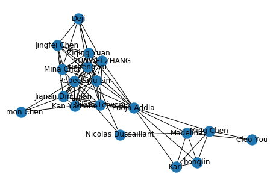

```python
G = nx.Graph(SNAdata)
nx.draw(G, with_labels=True)
```

```python
density = nx.density(G)
print('The edge density is:','%.3f' % (density))
```

```
The edge density is: 0.415
```

```python
degree = nx.degree(G)
degree
```

[output not shown]

```python
close=nx.closeness_centrality(G)
pd.DataFrame.from_dict(close,orient='index').sort_values(by=0,ascending=False)
```

|  | 0 |
| --- | --- |
| Pooja Addla | 0.750000 |
| Siyu Lin | 0.720000 |
| YUNWEI ZHANG | 0.692308 |
| Ziqing Yuan | 0.692308 |
| sicheng xu | 0.692308 |
| Jianan Dingqian | 0.666667 |
| Kan Yamane | 0.666667 |
| Rebecca | 0.642857 |
| Nikita Tejwani | 0.620690 |
| Madeline | 0.545455 |
| Jingfei Chen | 0.529412 |
| Mina Choi | 0.529412 |
| Nicolas Dussaillant | 0.529412 |
| Ming Chen | 0.514286 |
| Karl | 0.500000 |
| honglin | 0.500000 |
| Deji | 0.486486 |
| Simon Chen | 0.428571 |
| Cleo You | 0.367347 |

```python
pd.DataFrame(degree).sort_values(by=1,ascending=False)
```

|  | 0 | 1 |
| --- | --- | --- |
| 5 | Pooja Addla | 12 |
| 10 | Siyu Lin | 12 |
| 17 | YUNWEI ZHANG | 11 |
| 8 | sicheng xu | 11 |
| 11 | Ziqing Yuan | 11 |
| 9 | Jianan Dingqian | 10 |
| 16 | Kan Yamane | 10 |
| 2 | Rebecca | 9 |
| 12 | Jingfei Chen | 8 |
| 3 | Nikita Tejwani | 8 |
| 13 | Mina Choi | 7 |
| 15 | Deji | 6 |
| 18 | Madeline | 6 |
| 1 | Ming Chen | 5 |
| 7 | Karl | 4 |
| 6 | honglin | 4 |
| 4 | Simon Chen | 3 |
| 0 | Nicolas Dussaillant | 3 |
| 14 | Cleo You | 2 |

closeness centrality measures "how quickly" a node can travel to the rest of the graph

```python
between = nx.betweenness_centrality(G)
pd.DataFrame.from_dict(between, orient = 'index').sort_values(by=0,ascending=False)
```

|  | 0 |
| --- | --- |
| Pooja Addla | 0.363663 |
| Siyu Lin | 0.092655 |
| Madeline | 0.087831 |
| Ming Chen | 0.043542 |
| Kan Yamane | 0.042367 |
| Jianan Dingqian | 0.042367 |
| sicheng xu | 0.037340 |
| Ziqing Yuan | 0.037340 |
| YUNWEI ZHANG | 0.037340 |
| Rebecca | 0.029879 |
| Nicolas Dussaillant | 0.028494 |
| Mina Choi | 0.019367 |
| Jingfei Chen | 0.007096 |
| honglin | 0.000000 |
| Karl | 0.000000 |
| Simon Chen | 0.000000 |
| Nikita Tejwani | 0.000000 |
| Cleo You | 0.000000 |
| Deji | 0.000000 |

```python
from networkx.algorithms.community.modularity_max import greedy_modularity_communities
c = list(greedy_modularity_communities(G))
len(c)
```

```
2
```

```python
community_0 = sorted(c[0])
community_1 = sorted(c[1])

print(community_0)
print(community_1)
```

```
['Deji', 'Jianan Dingqian', 'Jingfei Chen', 'Kan Yamane', 'Mina Choi', 'Nicolas Dussaillant', 'Nikita Tejwani', 'Rebecca', 'Simon Chen', 'Siyu Lin', 'YUNWEI ZHANG', 'Ziqing Yuan', 'sicheng xu']
['Cleo You', 'Karl', 'Madeline', 'Ming Chen', 'Pooja Addla', 'honglin']
```

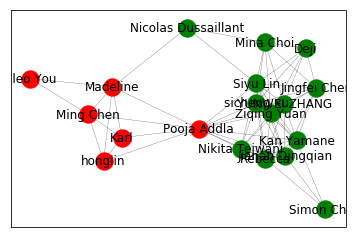

```python
pos = nx.spring_layout(G)

nx.draw_networkx_nodes(G,pos=pos,nodelist=community_0,node_color='green',label=True)
nx.draw_networkx_nodes(G, pos = pos, nodelist=community_1, node_color='red', label = True)

nx.draw_networkx_edges(G, pos = pos, width = 0.2)

nx.draw_networkx_labels(G, pos=pos)

plt.show()
```

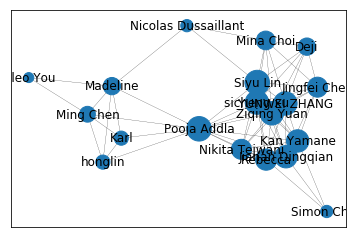

```python
nx.draw_networkx_nodes(G,pos=pos,nodelist=dict(degree).keys(),node_size= [v * 50 for v in dict(degree).values()], label = True)

nx.draw_networkx_edges(G, pos = pos, width = 0.2)

nx.draw_networkx_labels(G, pos=pos)

plt.show()
```

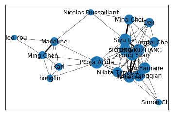

```python
eWeight = nx.get_edge_attributes(G,'weight')

nx.draw_networkx_nodes(G, pos = pos, nodelist = dict(degree).keys(), node_size = [v * 50 for v in dict(degree).values()], label = True)
nx.draw_networkx_edges(G,pos, width = [5**e/10 for e in eWeight.values()])
nx.draw_networkx_labels(G, pos=pos)

plt.show()
```

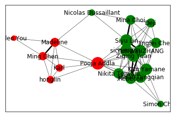

```python
# Degrees of each community
community_0_degree = {c: dict(degree)[c] for c in community_0}
community_1_degree = {c: dict(degree)[c] for c in community_1}

# Print out the nodes with color and size
nx.draw_networkx_nodes(G, pos = pos,
                       nodelist=community_0,
                       node_color='green',
                       node_size = [v * 50 for v in community_0_degree.values()],
                       label = True)

nx.draw_networkx_nodes(G, pos = pos,
                       nodelist=community_1,
                       node_size = [v * 50 for v in community_1_degree.values()],
                       node_color='red', label = True)

# Print out the edges with proper width
nx.draw_networkx_edges(G,pos, width = [5**e/10 for e in eWeight.values()])

# Make sure the label is printed
nx.draw_networkx_labels(G, pos=pos)

# Show the plot so it supress the other networkx outputs
plt.show()
```